# Midterm Exam

```r
# install.packages("dplyr")
# install.packages("magrittr")
library(dplyr)
library(magrittr) # for the pipe
```

### Instructions

There are 8 questions on this exam worth a total of 100 points. There’s a bonus question too.

Assume the signicance level $\alpha=.05$ on every question that involves hypothesis testing unless the problem says otherwise.

Running code and dumping results to the screen is not the same as answering a question or explaining your conclusion. That’s why the exam says ##### ———-Replace this text with your response.———– on most of the questions. Use R to get your results and refer to them in your written response. Keep the ##### and the —– so your anwers are easy to see.

### Problem (15 pts)

Use the file* **penguins.exam.csv** for this problem. It contains body measurements for over 100 Gentoo penguins observed in the Palmer Archipelago of Antarctica from 2007-2009. The images show what the measurements mean. Here we will work with bill length and flipper length.

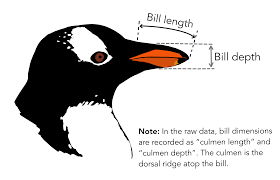

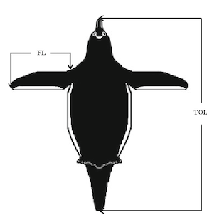

#### (a) (4 pts) Fit a SLR model where bill length is the predictor and flipper_length is the response. Display the regression output. Compute 98% confidence intervals for the intercept and slope coefficients.

```r
###
penguins.exam <- read.csv("~/Downloads/penguins.exam.csv")
head(penguins.exam)
```

|  | species | island | bill_length_mm | bill_depth_mm | flipper_length_mm | body_mass_g | sex | year |
| --- | --- | --- | --- | --- | --- | --- | --- | --- |
| 1 | Gentoo | Biscoe | 46.1 | 13.2 | 211 | 4500 | female | 2007 |
| 2 | Gentoo | Biscoe | 50.0 | 16.3 | 230 | 5700 | male | 2007 |
| 3 | Gentoo | Biscoe | 48.7 | 14.1 | 210 | 4450 | female | 2007 |
| 4 | Gentoo | Biscoe | 50.0 | 15.2 | 218 | 5700 | male | 2007 |
| 5 | Gentoo | Biscoe | 47.6 | 14.5 | 215 | 5400 | male | 2007 |
| 6 | Gentoo | Biscoe | 46.5 | 13.5 | 210 | 4550 | female | 2007 |

```r
dim(penguins.exam)
```

```
[1] 117   8
```

```r
penguins.mod <- lm(flipper_length_mm~bill_length_mm, data = penguins.exam) ##fit the model
summary(penguins.mod) ##display the result
```

```
Call:
lm(formula = flipper_length_mm ~ bill_length_mm, data = penguins.exam)

Residuals:
     Min       1Q   Median       3Q      Max
-11.0784  -3.2894   0.2164   3.2683  11.0690

Coefficients:
               Estimate Std. Error t value Pr(>|t|)
(Intercept)    147.2937     7.1759  20.526   <2e-16 ***
bill_length_mm   1.4740     0.1509   9.767   <2e-16 ***
---
Signif. codes:  0 ‘***’ 0.001 ‘**’ 0.01 ‘*’ 0.05 ‘.’ 0.1 ‘ ’ 1

Residual standard error: 4.752 on 115 degrees of freedom
Multiple R-squared:  0.4534,    Adjusted R-squared:  0.4486
F-statistic: 95.39 on 1 and 115 DF,  p-value: < 2.2e-16
```

```r
confint(penguins.mod, level = 0.98) ##CI's for intercept and slope
```

```
                      1 %       99 %
(Intercept)    130.364149 164.223264
bill_length_mm   1.117962   1.830076
```

```r
summary(penguins.mod)$sigma ##estimate of sigma
```

```
[1] 4.75245
```

#### (b) (4 pts) What proportion of the variation in flipper length is explained by bill length?

##### ———-As we can see from the display of regression output, the model can explain the 45.34% of fliiper length on bill length.———–

#### (c) (3 pts) What is the estimate of $\sigma$, the standard deviation of the errors?

##### ———-The estimate sigma is 4.75245.———–

#### (d) (4 pts) Make a plot with the data points and the fitted regression line.

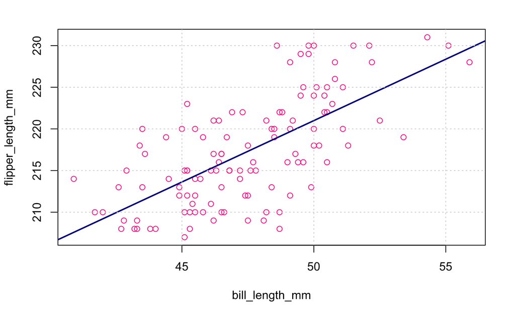

```r
plot(flipper_length_mm~bill_length_mm, data = penguins.exam, col='deeppink'); abline(penguins.mod, col = 'darkblue', lwd = 2)
grid()
```

### Problem (12 pts)

#### (a) (6 pts) Make a data.frame called `mydata` with 5 rows and 2 columns called `xvec` and `yvec`. The values in `xvec` are given below. You pick the values in `yvec`. Select $y$ values so that the slope coefficent is negative when you fit the simple linear regression model `yvec ~ xvec`. Display the regression output for your fitted model.

```r
xvec <- c(2.2, 4.0, 5.6, 8.1, 9.6)

#yvec <- ???
yvec <- c(8.2, 7.1, 6.3, 3.2, 2.1)

#data frame
mydata <- data.frame(xvec, yvec)

#display the regression output
mydata.mod = lm(yvec~xvec, data = mydata)
summary(mydata.mod)
```

```
Call:
lm(formula = yvec ~ xvec, data = mydata)

Residuals:
       1        2        3        4        5
-0.36394  0.08501  0.66184 -0.28685 -0.09606

Coefficients:
            Estimate Std. Error t value Pr(>|t|)
(Intercept) 10.45709    0.51068   20.48 0.000255 ***
xvec        -0.86052    0.07881  -10.92 0.001644 **
---
Signif. codes:  0 ‘***’ 0.001 ‘**’ 0.01 ‘*’ 0.05 ‘.’ 0.1 ‘ ’ 1

Residual standard error: 0.4723 on 3 degrees of freedom
Multiple R-squared:  0.9755,    Adjusted R-squared:  0.9673
F-statistic: 119.2 on 1 and 3 DF,  p-value: 0.001644
```

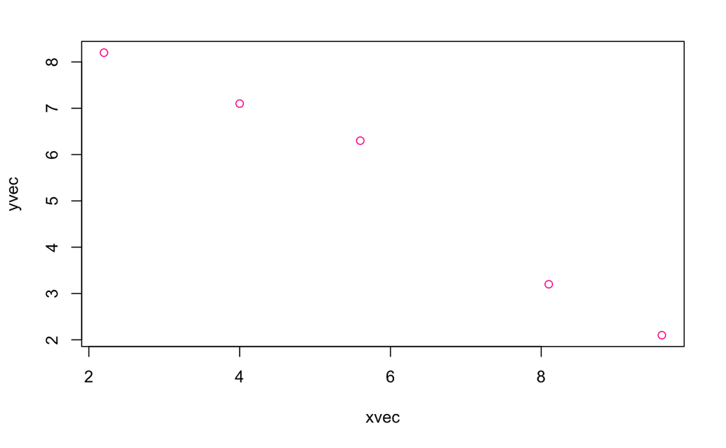

```r
#make scatter plot
plot(yvec~xvec, data = mydata, col='deeppink')
```

#### (b) (6 pts) Is there a significant linear relationship between `yvec` and `xvec`? Justify your answer.

##### ———-The p-value of the slope is 0.001644 which is nearly 0 (less than 0.05). Also, the model can explain 97.55% of yxec on xvec, therefore we can conclude that there is a statistically significant linear relationship between yvec and xvec ———–

### Problem (10 pts)

#### (a) (5 pts) Using your `yvec ~ xvec` model from the previous question, find the leverages of the five data points. Identify any points which are high leverage.

```r
# check leverage points using Cooks Distance
subset(cooks.distance(mydata.mod), cooks.distance(mydata.mod) > 4/(nrow(mydata)- 2))
```

```
named numeric(0)
```

#### (b) (5 pts) Build `mydata` again but change it so that one data point has **high leverage** when you refit the model. This may require trial and error. Display the leverages for your final version of `mydata` and identify the data point with high leverage.

##### ———-The observation numbered as 5 is the high leverage data point.———–

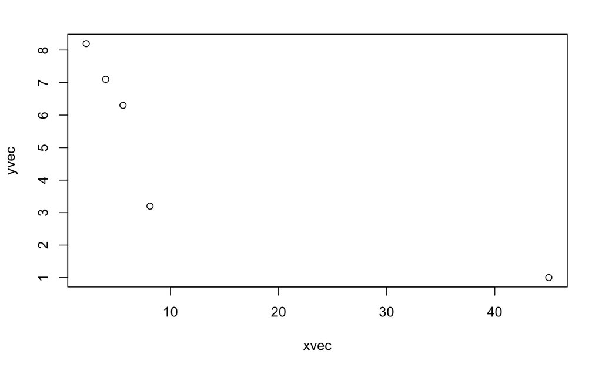

```r
###rebuid
xvec <- c(2.2, 4.0, 5.6, 8.1, 45)

#yvec <- ???
yvec <- c(8.2, 7.1, 6.3, 3.2, 1)

#data frame
mydata <- data.frame(xvec, yvec)

mydata.mod <- lm(yvec~xvec, data = mydata)
plot(yvec~xvec, data = mydata)


#plotting
par(mfrow=c(3, 2))
```

[figure not shown]

```r
plot(mydata1.mod)
```

```r
#Leverage and Standardized Residuals table
table <- data.frame(Case = 1:nrow(mydata),
                    xvec = mydata$xvec,
                    yvec = mydata$yvec,
                    Residuals = mydata.mod$residuals,
                    leverage = lm.influence(mydata.mod)$hat,
                    StdResiduals = rstandard(mydata.mod))
table
```

|  | Case | xvec | yvec | Residuals | leverage | StdResiduals |
| --- | --- | --- | --- | --- | --- | --- |
| 1 | 1 | 2.2 | 8.2 | 1.5292508 | 0.2893630 | 0.99802742 |
| 2 | 2 | 4.0 | 7.1 | 0.6815095 | 0.2620116 | 0.43645030 |
| 3 | 3 | 5.6 | 6.3 | 0.1057394 | 0.2418825 | 0.06681229 |
| 4 | 4 | 8.1 | 3.2 | -2.6439013 | 0.2183130 | -1.64519147 |
| 5 | 5 | 45.0 | 1.0 | 0.3274016 | 0.9884298 | 1.67454828 |

```r
leverage_points <- subset(table, leverage > (4/nrow(mydata)))
leverage_points
```

|  | Case | xvec | yvec | Residuals | leverage | StdResiduals |
| --- | --- | --- | --- | --- | --- | --- |
| 5 | 5 | 45 | 1 | 0.3274016 | 0.9884298 | 1.674548 |

```r
NA
NA
```

### Problem (10 pts)

Use the file **airfares.exam.txt** for this problem. (This file is not the same as **airfares.txt**.)

#### Fit a simple linear regression model for $y$ = `Fare` as a function of $x$ = `Distance`. Is there a significant linear relationship between `Fare` and `Distance`? Justify your answer.

##### ———-The p-value of the slope is 0.059930 which is greater than 0.05. Also, the model can only explain 21.63% of Distance on Fare, therefore we fail to reject the null hypothesis. There is no statistically significant linear relationship between Fare and Distance.———–

```r
###
airfares.exam <- read.delim("~/Downloads/airfares.exam.txt")
head(airfares.exam)
```

|  | City | Fare | Distance |
| --- | --- | --- | --- |
| 1 | 1 | 360 | 191.683399 |
| 2 | 2 | 360 | 225.439644 |
| 3 | 3 | 207 | -151.477487 |
| 4 | 4 | 111 | 2.716963 |
| 5 | 5 | 93 | 47.958215 |
| 6 | 6 | 141 | 266.908188 |

```r
dim(airfares.exam)
```

```
[1] 17  3
```

```r
airfares.mod <- lm(Fare~Distance, data = airfares.exam) ##fit the model
summary(airfares.mod) ##display the result
```

```
Call:
lm(formula = Fare ~ Distance, data = airfares.exam)

Residuals:
    Min      1Q  Median      3Q     Max
-168.74  -99.17   -5.21  103.55  200.57

Coefficients:
            Estimate Std. Error t value Pr(>|t|)
(Intercept) 168.1672    41.2610   4.076 0.000994 ***
Distance      0.4606     0.2263   2.035 0.059930 .
---
Signif. codes:  0 ‘***’ 0.001 ‘**’ 0.01 ‘*’ 0.05 ‘.’ 0.1 ‘ ’ 1

Residual standard error: 118.6 on 15 degrees of freedom
Multiple R-squared:  0.2163,    Adjusted R-squared:  0.1641
F-statistic: 4.141 on 1 and 15 DF,  p-value: 0.05993
```

### Problem (14 pts)

#### (a) (10 points) Run the code below to build data.frame `Thermometers` with columns `Celsius` and `Fahrenheit`. Fit the simple linear regression model where `Celsius` is the predictor and `Fahrenheit` is the response. Make a scatter plot of the data. Plot each data point as a red circle. Add curves for the fitted regression line, the boundaries of a 90% confidence interval for the regression line, and the boundaries of a 90% prediction interval for Fahrenheit. Make the curves different colors and identify them in your discussion. A legend is not required.

##### ———-As we can see in the plot, the blue lines color represents for the boundaries of a 90% confidence interval and the deeppink lines color represents for a 90% prediction interval; it is WIDER than the confidence interval boundaries. .———–

```r
set.seed(24681012)
Celsius <- c(-5, 0, 4, 11, 17, 22, 30, 37)
Fahrenheit <- 32 + 1.8*Celsius + rnorm(length(Celsius), 0, 8)
Thermometers <- data.frame(Celsius, Fahrenheit)
# Fit the SLR model
thermometers.mod <- lm(Fahrenheit~Celsius, data=Thermometers)
summary(thermometers.mod)
```

```
Call:
lm(formula = Fahrenheit ~ Celsius, data = Thermometers)

Residuals:
    Min      1Q  Median      3Q     Max
-10.561  -1.922  -0.247   2.925  10.593

Coefficients:
            Estimate Std. Error t value Pr(>|t|)
(Intercept)   28.309      3.482    8.13 0.000186 ***
Celsius        1.858      0.174   10.68 3.98e-05 ***
---
Signif. codes:  0 ‘***’ 0.001 ‘**’ 0.01 ‘*’ 0.05 ‘.’ 0.1 ‘ ’ 1

Residual standard error: 6.788 on 6 degrees of freedom
Multiple R-squared:   0.95, Adjusted R-squared:  0.9417
F-statistic:   114 on 1 and 6 DF,  p-value: 3.979e-05
```

```r
# Make scatter plot and add curves

plot(Fahrenheit~Celsius, data=Thermometers, pch=16, col='red')
xvec <- seq(min(Thermometers$Celsius), max(Thermometers$Celsius), by =  5)
matplot(xvec, predict.lm(thermometers.mod, newdata = data.frame(Celsius = xvec), interval = 'conf', level = 0.90), col = c('black', rep('blue',2)), type = 'l', add = T)
```

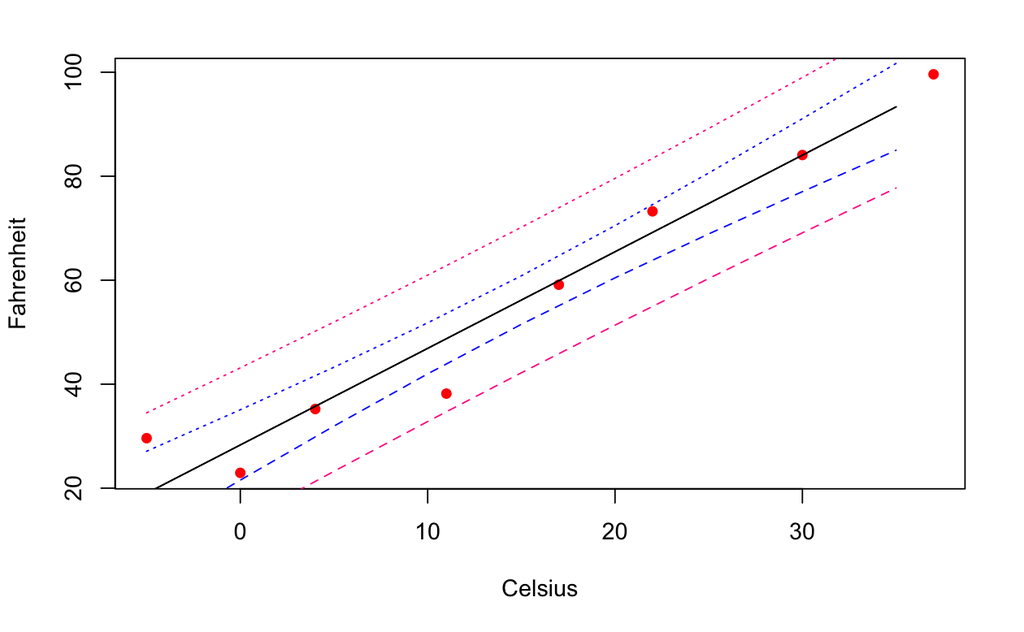

```r
matplot(xvec, predict.lm(thermometers.mod, newdata = data.frame(Celsius = xvec), interval = 'pred', level = 0.90), col = c('black', rep('deeppink',2)), type = 'l', add = T)
```

```r
NA
NA
```

### Problem (17 pts)

Use the file **trees.csv** for this problem. This dataset measures diameter (in inches), circumference (in inches), and volume (in cubic feet) for 70 shortleaf pine trees.

#### (a) (8 pts) Fit a simple linear regression model called `tree_model_1` to predict circumference as a function of diameter. Use the model to predict `Circ` when `Diam` = 21 inches. (`tree_model_1` also gets used in the next problem)

##### ———-By using the model, we can make the prediction that when value of Diam is 21, we are 95% condident that the value of Circ will fall in between 58.26959 and 84.93974.———–

```r
### Read trees.csv file
trees <- read.csv("~/Downloads/trees.csv")
head(trees)
```

|  | Diam | Vol | Circ |
| --- | --- | --- | --- |
| 1 | 4.4 | 2.0 | 10.42 |
| 2 | 4.6 | 2.2 | 10.18 |
| 3 | 5.0 | 3.0 | 27.20 |
| 4 | 5.1 | 4.3 | 25.70 |
| 5 | 5.1 | 3.0 | 24.76 |
| 6 | 5.2 | 2.9 | 16.44 |

```r
###fit SLR model

tree_model_1 <- lm(Circ ~ Diam, data = trees)
summary(tree_model_1)
```

```
Call:
lm(formula = Circ ~ Diam, data = trees)

Residuals:
     Min       1Q   Median       3Q      Max
-13.4116  -3.8225  -0.6854   4.0576  15.8194

Coefficients:
            Estimate Std. Error t value Pr(>|t|)
(Intercept)  -2.0875     2.2152  -0.942    0.349
Diam          3.5091     0.1859  18.872   <2e-16 ***
---
Signif. codes:  0 ‘***’ 0.001 ‘**’ 0.01 ‘*’ 0.05 ‘.’ 0.1 ‘ ’ 1

Residual standard error: 6.383 on 68 degrees of freedom
Multiple R-squared:  0.8397,    Adjusted R-squared:  0.8373
F-statistic: 356.2 on 1 and 68 DF,  p-value: < 2.2e-16
```

```r
###predict Circ when Diam = 21 inches
predict.lm(tree_model_1, data.frame(Diam = 21), interval = 'pred', level = 0.95)
```

```
       fit      lwr      upr
1 71.60467 58.26959 84.93974
```

#### (b) (9 pts) Find the total sum of squares, the residual sum of squares, and the regression sum of squares based on `tree_model_1`. Write a sentence where you give the value of each of these quantities.

```r
###
tree.aov = anova(tree_model_1)

SSR <- tree.aov$`Sum Sq`[1] ## Regression sum of squares
SSR
```

```
[1] 14511.87
```

```r
SSE <- tree.aov$`Sum Sq`[2] ## Residual sum of squares
SSE
```

```
[1] 2770.654
```

```r
SST <- SSR + SSE ## Total sum of squares
SST
```

```
[1] 17282.52
```

### Problem (14 pts)

This problem also uses **trees.csv**.

#### (a) (6 pts) Fit a SLR model called `tree_model_2` where the response is `Vol` and the predictor is `Diam`. Use the model to answer these questions: Which points have high leverage? Which points are outliers? Which points are influential based on Cook’s distance?

##### ———-Observations numbered as 67, 68, 69, 70 are considered as high leverage. The outlier is the observation #70.

```
          Based on Cook's distance, we indentified observations numbered as 68, 69, 70 are influential points. -----------
```

```r
### Fit a SLR model called tree_model_2
tree_model_2 <-  lm(Vol~Diam, data=trees)

### Leverage and Standardized Residuals table
table <- data.frame(Case = 1:nrow(trees),
                    Diam = trees$Diam,
                    Distance = trees$Vol,
                    Residuals = tree_model_2$residuals,
                    leverage = lm.influence(tree_model_2)$hat,
                    StdResiduals = rstandard(tree_model_2))
table
```

|  | Case | Diam | Distance | Residuals | leverage | StdResiduals |
| --- | --- | --- | --- | --- | --- | --- |
| 1 | 1 | 4.4 | 2.0 | 13.48653206 | 0.05334180 | 1.403696673 |
| 2 | 2 | 4.6 | 2.2 | 12.31918852 | 0.05107301 | 1.280664238 |
| 3 | 3 | 5.0 | 3.0 | 10.38450143 | 0.04673907 | 1.077083405 |
| 4 | 4 | 5.1 | 4.3 | 11.00082966 | 0.04569801 | 1.140386603 |
| 5 | 5 | 5.1 | 3.0 | 9.70082966 | 0.04569801 | 1.005623805 |
| 6 | 6 | 5.2 | 2.9 | 8.91715789 | 0.04467392 | 0.923889905 |
| 7 | 7 | 5.2 | 3.5 | 9.51715789 | 0.04467392 | 0.986054773 |
| 8 | 8 | 5.5 | 3.4 | 7.36614257 | 0.04170349 | 0.762008384 |
| 9 | 9 | 5.5 | 5.0 | 8.96614257 | 0.04170349 | 0.927524242 |
| 10 | 10 | 5.6 | 7.2 | 10.48247080 | 0.04074729 | 1.083843871 |

[output cut: 60 more lines]

```r
leverage_points <- subset(table, leverage > (4/nrow(trees))) ### detecting leverage points
leverage_points
```

|  | Case | Diam | Distance | Residuals | leverage | StdResiduals |
| --- | --- | --- | --- | --- | --- | --- |
| 67 | 67 | 18.3 | 93.8 | 10.25616 | 0.05725098 | 1.069686 |
| 68 | 68 | 18.3 | 97.9 | 14.35616 | 0.05725098 | 1.497303 |
| 69 | 69 | 19.4 | 107.0 | 15.93577 | 0.07156151 | 1.674812 |
| 70 | 70 | 23.4 | 163.5 | 45.08890 | 0.14091035 | 4.926290 |

```r
outliers <- subset(leverage_points, abs(StdResiduals) > 2) ### identifying outliers
outliers
```

|  | Case | Diam | Distance | Residuals | leverage | StdResiduals |
| --- | --- | --- | --- | --- | --- | --- |
| 70 | 70 | 23.4 | 163.5 | 45.0889 | 0.1409103 | 4.92629 |

```r
subset(cooks.distance(tree_model_2), cooks.distance(tree_model_2) > 4/(nrow(trees)- 2)) ### influential points using Cooks Distance
```

```
        68         69         70
0.06807321 0.10810065 1.99028042
```

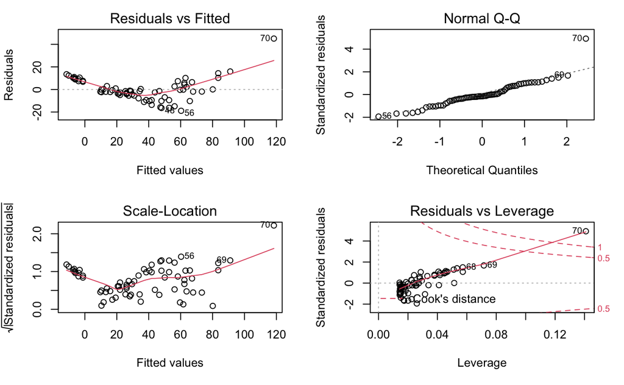

```r
### diagnostic plots
par(mfrow=c(2,2))
plot(tree_model_2)
```

#### (b) (4 pts) Plot the residuals of `tree_model_2` versus $x=$ `Diam`. What does the plot suggest about the validity of `tree_model_2`?

##### ———-From the residuals vs fitted model, it’s not a straight line, so between predictor and response does not show a linear relationship. Linerity assumption is violated, therefore this model is invalid. ———–

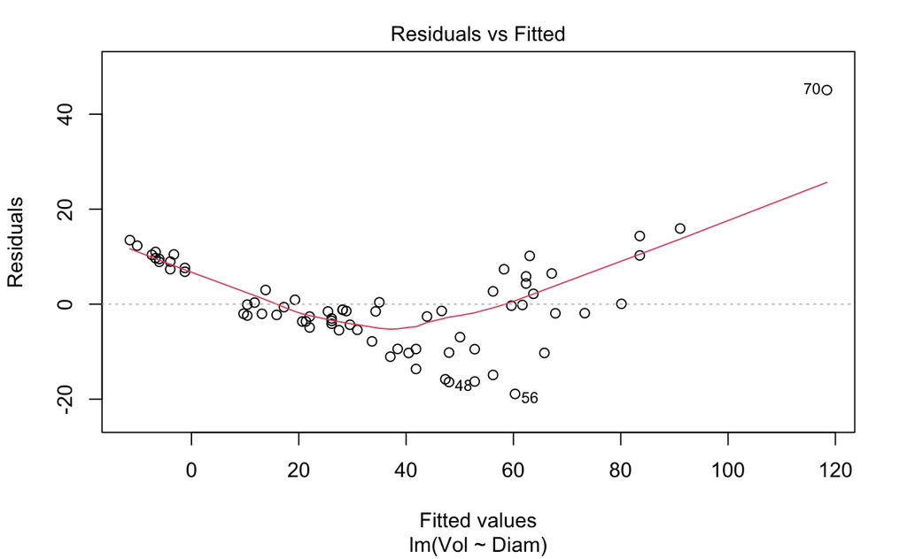

```r
### Residuals of tree_model_2 vs x
plot(tree_model_2, which = 1)
```

#### (c) (4 pts) Make and interpret the same plot for `tree_model_1`.

##### ———-From the residuals vs fitted model, the trend line is close to the dashed line, so between predictor and response show a linear relationship. The linearity seems to hold reasonably well, therefore this model is valid. .———–

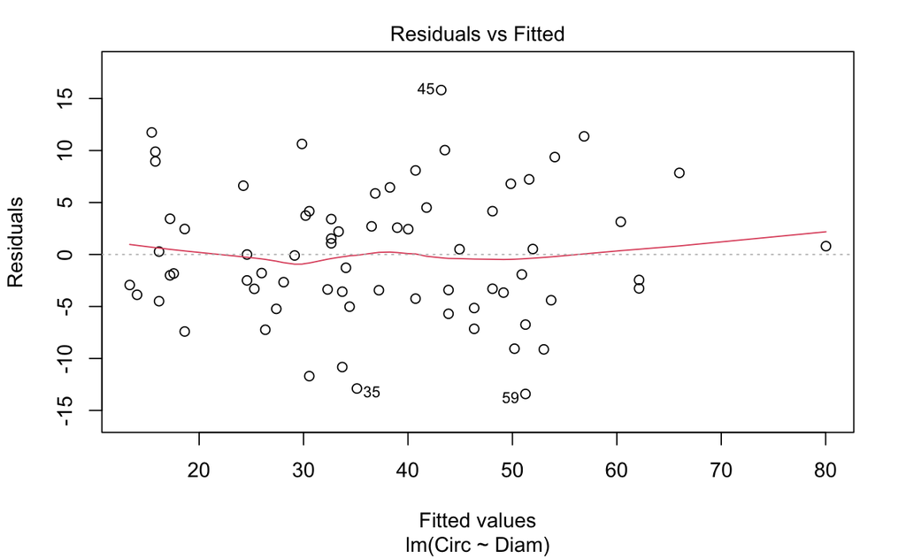

```r
###Residuals of tree_model_1 vs x
plot(tree_model_1, which = 1)
```

### Problem (8 pts)

This problem uses the penguin data from earlier.

#### Split the penguin data into two subsets, one for female penguins and one for males. Repeat parts (a), (b), (c), and (d) from the earlier problem for each subset.

```r
## split up penguin data
penguins.male <- penguins.exam %>% filter(sex == "male") ### males penguins
head(penguins.male)
```

|  | species | island | bill_length_mm | bill_depth_mm | flipper_length_mm | body_mass_g | sex | year |
| --- | --- | --- | --- | --- | --- | --- | --- | --- |
| 1 | Gentoo | Biscoe | 50.0 | 16.3 | 230 | 5700 | male | 2007 |
| 2 | Gentoo | Biscoe | 50.0 | 15.2 | 218 | 5700 | male | 2007 |
| 3 | Gentoo | Biscoe | 47.6 | 14.5 | 215 | 5400 | male | 2007 |
| 4 | Gentoo | Biscoe | 46.7 | 15.3 | 219 | 5200 | male | 2007 |
| 5 | Gentoo | Biscoe | 46.8 | 15.4 | 215 | 5150 | male | 2007 |
| 6 | Gentoo | Biscoe | 49.0 | 16.1 | 216 | 5550 | male | 2007 |

```r
dim(penguins.male)
```

```
[1] 60  8
```

```r
penguins.female <- penguins.exam %>% filter(sex == "female") ### female penguins
head(penguins.female)
```

|  | species | island | bill_length_mm | bill_depth_mm | flipper_length_mm | body_mass_g | sex | year |
| --- | --- | --- | --- | --- | --- | --- | --- | --- |
| 1 | Gentoo | Biscoe | 46.1 | 13.2 | 211 | 4500 | female | 2007 |
| 2 | Gentoo | Biscoe | 48.7 | 14.1 | 210 | 4450 | female | 2007 |
| 3 | Gentoo | Biscoe | 46.5 | 13.5 | 210 | 4550 | female | 2007 |
| 4 | Gentoo | Biscoe | 45.4 | 14.6 | 211 | 4800 | female | 2007 |
| 5 | Gentoo | Biscoe | 43.3 | 13.4 | 209 | 4400 | female | 2007 |
| 6 | Gentoo | Biscoe | 40.9 | 13.7 | 214 | 4650 | female | 2007 |

```r
dim(penguins.female)
```

```
[1] 57  8
```

```r
## male penguins data set

penguins.male.mod <- lm(flipper_length_mm~bill_length_mm, data = penguins.male) ### fit the model
summary(penguins.male.mod) ##display the result
```

```
Call:
lm(formula = flipper_length_mm ~ bill_length_mm, data = penguins.male)

Residuals:
     Min       1Q   Median       3Q      Max
-12.6970  -3.6451   0.7554   3.2149   9.4192

Coefficients:
               Estimate Std. Error t value Pr(>|t|)
(Intercept)    164.1111    13.1534  12.477  < 2e-16 ***
bill_length_mm   1.1619     0.2665   4.361 5.38e-05 ***
---
Signif. codes:  0 ‘***’ 0.001 ‘**’ 0.01 ‘*’ 0.05 ‘.’ 0.1 ‘ ’ 1

Residual standard error: 4.912 on 58 degrees of freedom
Multiple R-squared:  0.2469,    Adjusted R-squared:  0.2339
F-statistic: 19.01 on 1 and 58 DF,  p-value: 5.384e-05
```

```r
confint(penguins.male.mod, level = 0.98) ### CI's interval
```

```
                       1 %       99 %
(Intercept)    132.6431633 195.578968
bill_length_mm   0.5244423   1.799417
```

#### (b) What proportion of the variation in flipper length is explained by bill length?

##### ———-As we can see from the display of regression output, the model can explain the 24.69 %.———–

#### (c) What is the estimate of $\sigma$, the standard deviation of the errors?

##### ———-The estimate sigma is 4.912 ———–

#### (d) Make a plot with the data points and the fitted regression line.

[figure not shown]

```r
plot(flipper_length_mm~bill_length_mm, data = penguins.male, col='deeppink'); abline(penguins.mod, col = 'darkblue', lwd = 2)
grid()
```

```r
## female penguins data set

penguins.female.mod <- lm(flipper_length_mm~bill_length_mm, data = penguins.female) ##fit the model
summary(penguins.female.mod) ##display the result
```

```
Call:
lm(formula = flipper_length_mm ~ bill_length_mm, data = penguins.female)

Residuals:
   Min     1Q Median     3Q    Max
-5.659 -2.870 -0.553  2.341  8.391

Coefficients:
               Estimate Std. Error t value Pr(>|t|)
(Intercept)    188.8482    10.7213  17.614   <2e-16 ***
bill_length_mm   0.5279     0.2353   2.243   0.0289 *
---
Signif. codes:  0 ‘***’ 0.001 ‘**’ 0.01 ‘*’ 0.05 ‘.’ 0.1 ‘ ’ 1

Residual standard error: 3.582 on 55 degrees of freedom
Multiple R-squared:  0.08384,   Adjusted R-squared:  0.06718
F-statistic: 5.033 on 1 and 55 DF,  p-value: 0.02892
```

```r
confint(penguins.female.mod, level = 0.98) ### CI's interval
```

```
                        1 %       99 %
(Intercept)    163.15920127 214.537199
bill_length_mm  -0.03591957   1.091813
```

#### (d) Make a plot with the data points and the fitted regression line.

[figure not shown]

```r
plot(flipper_length_mm~bill_length_mm, data = penguins.female, col='deeppink'); abline(penguins.mod, col = 'darkblue', lwd = 2)
grid()
```

### Bonus problem (5 points)

#### Rework the thermometer problem but make `Fahrenheit` the predictor and `Celsius` the response. Values for `Fahrenheit` are given to help you get started.

```r
set.seed(24681012)
Fahrenheit <- c(23, 32, 39.2, 51.8, 62.6, 71.6, 86, 98.6)
Celsius <- (Fahrenheit - 32) * 5/9 + rnorm(length(Fahrenheit), 0, 8)
Thermometers <- data.frame(Fahrenheit, Celsius)
###


# Fit the SLR model
thermometers.mod1 <- lm(Celsius~Fahrenheit, data=Thermometers)
summary(thermometers.mod1)
```

```
Call:
lm(formula = Celsius ~ Fahrenheit, data = Thermometers)

Residuals:
    Min      1Q  Median      3Q     Max
-10.561  -1.922  -0.247   2.925  10.593

Coefficients:
             Estimate Std. Error t value Pr(>|t|)
(Intercept) -22.49820    6.10705  -3.684 0.010282 *
Fahrenheit    0.58772    0.09666   6.080 0.000899 ***
---
Signif. codes:  0 ‘***’ 0.001 ‘**’ 0.01 ‘*’ 0.05 ‘.’ 0.1 ‘ ’ 1

Residual standard error: 6.788 on 6 degrees of freedom
Multiple R-squared:  0.8604,    Adjusted R-squared:  0.8371
F-statistic: 36.97 on 1 and 6 DF,  p-value: 0.0008994
```

```r
# Make scatter plot and add curves

plot(Celsius~Fahrenheit, data=Thermometers, col='red')
xvec <- seq(min(Thermometers$Fahrenheit), max(Thermometers$Fahrenheit), by =  5)
matplot(xvec, predict.lm(thermometers.mod1, newdata = data.frame(Fahrenheit = xvec), interval = 'conf', level = 0.90), col = c('black', rep('blue',2)), type = 'l', add = T)
```

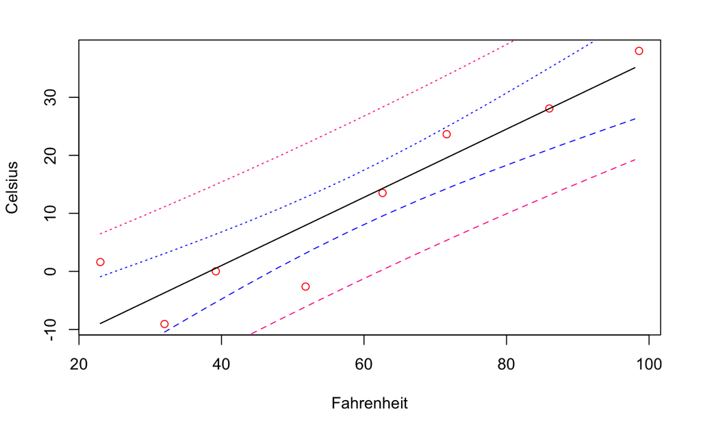

```r
matplot(xvec, predict.lm(thermometers.mod1, newdata = data.frame(Fahrenheit = xvec),  interval = 'pred', level = 0.90), col = c('black', rep('deeppink',2)), type = 'l', add = T)
```

```r
### As we can see in the plot, the blue lines color represents for the boundaries of a 90% confidence interval and the deeppink lines color represents for a 90% prediction interval; it is WIDER than the confidence interval boundaries.
```